**NAME: DANIEL ADEEKO LANRE**

**STUDENT ID: 22554901**

# **Principles of Data Science Tasks to Perform**

The work on this assignment is driven by two main, broad data science questions:

1. What are the **best predictors** of the price of a vehicle? In other words, of the individual and interactions of pairs of features in the dataset, what are those that seem to have to strongest association with the feature price, and what are the explanations and insights behind those findings?
2. What are **interesting groupings of the data**, involving one or two features, that show significant differences (e.g., trends, averages) in price? What can we learn from them and how useful could these findings be for the business?

# **About the Dataset**

The data set is on **AutoTrader** vehicle registration - the dataset contain several columns of data that describe the public reference, maker, colour, fuel type, model, vehicle condition, mileage, price of vehicles.

The **public reference** is like a primary key/identifier for each entry in the dataset.

The **standard make** column contains different vehicle maker - Toyota, BMW, Audi etc.

The **Standard colour** specify the different colour of the vehicle in the dataset.

The S**tandard model** column contains different form of model series for particular make of vehicles.

The **vehicle condition** contains two types of vehicle condition - Old or New

The **year of registration** contains the year at which the vehicles are registered.

The **mileage** contains the various miles travelled by the vehicles

The **price** columns specify the selling price for each vehicle.

The **body_type** columns specify the body-type for each vehicle, either it is an SUV, Hatchback etc.

# Data Understanding and Exploration

### Meaning and Type of Features; Analysis of Distributions

Importing the necessary packages and setting up the environment

```python
import pandas as pd
import numpy as np
import seaborn as sns
import matplotlib.pyplot as plt
```

```python
data = pd.read_csv('https://raw.githubusercontent.com/adeekodaniel/DataScienceProj/main/adverts.csv') #I uploaded the dataset to my github account and used the link from github
```

```python
data.head() # to display the first 5 values of the dataset
```

|  | public_reference | mileage | reg_code | standard_colour | standard_make | standard_model | vehicle_condition | year_of_registration | price | body_type | crossover_car_and_van | fuel_type |
| --- | --- | --- | --- | --- | --- | --- | --- | --- | --- | --- | --- | --- |
| 0 | 202006039777689 | 0.0 | NaN | Grey | Volvo | XC90 | NEW | NaN | 73970 | SUV | False | Petrol Plug-in Hybrid |
| 1 | 202007020778260 | 108230.0 | 61 | Blue | Jaguar | XF | USED | 2011.0 | 7000 | Saloon | False | Diesel |
| 2 | 202007020778474 | 7800.0 | 17 | Grey | SKODA | Yeti | USED | 2017.0 | 14000 | SUV | False | Petrol |
| 3 | 202007080986776 | 45000.0 | 16 | Brown | Vauxhall | Mokka | USED | 2016.0 | 7995 | Hatchback | False | Diesel |
| 4 | 202007161321269 | 64000.0 | 64 | Grey | Land Rover | Range Rover Sport | USED | 2015.0 | 26995 | SUV | False | Diesel |

```python
data.shape #the shape method shows there are 402,005 rows and 12 columns in the dataset
```

```
(402005, 12)
```

```python
data.columns #columns method shows the names of each columns in the dataset.
```

```
Index(['public_reference', 'mileage', 'reg_code', 'standard_colour',
       'standard_make', 'standard_model', 'vehicle_condition',
       'year_of_registration', 'price', 'body_type', 'crossover_car_and_van',
       'fuel_type'],
      dtype='object')
```

```python
data.info() #Passing the info method on the dataset in order to view a general summary and information about the dataset, which includes the datatypes, range index etc
```

```
<class 'pandas.core.frame.DataFrame'>
RangeIndex: 402005 entries, 0 to 402004
Data columns (total 12 columns):
 #   Column                 Non-Null Count   Dtype
---  ------                 --------------   -----
 0   public_reference       402005 non-null  int64
 1   mileage                401878 non-null  float64
 2   reg_code               370148 non-null  object
 3   standard_colour        396627 non-null  object
 4   standard_make          402005 non-null  object
 5   standard_model         402005 non-null  object
 6   vehicle_condition      402005 non-null  object
 7   year_of_registration   368694 non-null  float64
 8   price                  402005 non-null  int64
 9   body_type              401168 non-null  object
 10  crossover_car_and_van  402005 non-null  bool
 11  fuel_type              401404 non-null  object
dtypes: bool(1), float64(2), int64(2), object(7)
memory usage: 34.1+ MB
```

From displaying the information about the dataset, I noticed some few things.

1. Year of registration data type shouldn't be float but integer - as year cannot be in decimal
2. There are some missing values in the data set - I have to find a way to go about it
3. In the data set; *there are 12 columns of which 7 are data types of object, 2 are integers, 2 are floats and we have 1 boolean column*

**Note:** In order to convert the data type of year of registration from float to integer, I will have to deal with the missing values. **I will see the data distribution of year of registration column and other columns**

I will categories the data into two set -

1. Categorical Variable
2. Numerical Variable

```python
categorical_variables = data.select_dtypes(include=["object", 'bool']).columns.tolist()
numerical_variables = data.select_dtypes(include=['int64', 'float64']).columns.tolist()
```

Checking the distribution of the numerical variables - Year of Registration, Price and Milage.

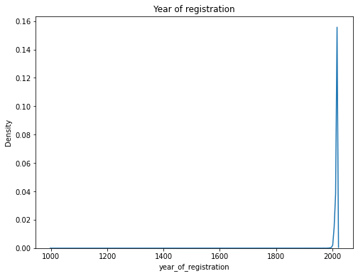

```python
plt.figure(figsize=(8,6))
plt.title('Year of registration')
sns.kdeplot(data['year_of_registration']); # I can see from the plot that there are less values for year less than 2000 and most of my data range from year 2000 upwards.
```

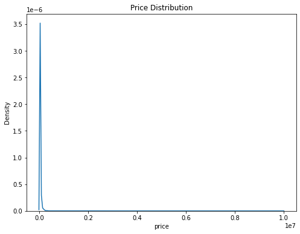

```python
plt.figure(figsize=(8,6))
plt.title('Price Distribution')
sns.kdeplot(data['price']); #The price graph is right skewed, I will attempt to use a log scale to make the chart more visually appealing.
```

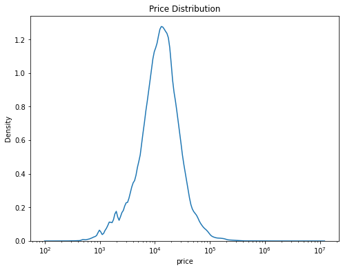

```python
plt.figure(figsize=(8,6))
plt.title('Price Distribution')
sns.kdeplot(data['price'], log_scale=True); # This makes the  distribution looks more better
```

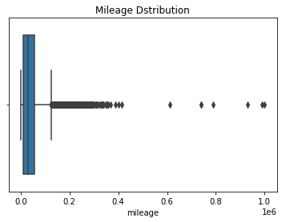

```python
sns.boxplot(x=data['mileage']);
plt.title('Mileage Dstribution') #The mileage chart shows the prevalence of outliers in the mileage feature
```

From the distribution we can see there a lot of outliers/noise in the price and mileage variable.

### Identification/Commenting on Missing Values

```python
data.isna().sum().sort_values() #to view the missing values in the dataset
```

```
public_reference             0
standard_make                0
standard_model               0
vehicle_condition            0
price                        0
crossover_car_and_van        0
mileage                    127
fuel_type                  601
body_type                  837
standard_colour           5378
reg_code                 31857
year_of_registration     33311
dtype: int64
```

Some questions to explore the features further -

1. Are there any used vehicles with Zero mileage?
2. Are there any used car with nan year of registration?
3. Are there any new car with nan year of registration?

**I will be dropping column registration code and public reference as both features are not important to the task.**

```python
data = data.drop(columns=['public_reference', 'reg_code']) #dropping the public reference and registration code column
data.sample()
```

|  | mileage | standard_colour | standard_make | standard_model | vehicle_condition | year_of_registration | price | body_type | crossover_car_and_van | fuel_type |
| --- | --- | --- | --- | --- | --- | --- | --- | --- | --- | --- |
| 180082 | 38600.0 | Grey | Audi | A4 Avant | USED | 2017.0 | 19995 | Estate | False | Diesel |

```python
data.loc[(data['mileage'] == 0.00) & (data['vehicle_condition'] == 'USED')] #we have 355 rows of vehicle which are used but have 0.00 mileage, and used vehicle should not have zero mileage but mileage that are greater than zero.
```

|  | mileage | standard_colour | standard_make | standard_model | vehicle_condition | year_of_registration | price | body_type | crossover_car_and_van | fuel_type |
| --- | --- | --- | --- | --- | --- | --- | --- | --- | --- | --- |
| 810 | 0.0 | Grey | Land Rover | Range Rover Velar | USED | 2020.0 | 52995 | SUV | False | Diesel |
| 1656 | 0.0 | Silver | Vauxhall | Insignia | USED | 2013.0 | 2975 | Hatchback | False | Diesel |
| 1855 | 0.0 | Grey | Mercedes-Benz | CLA Class | USED | 2020.0 | 34995 | Estate | False | Petrol |
| 2201 | 0.0 | Black | Land Rover | Range Rover | USED | 2020.0 | 82750 | SUV | False | Diesel |
| 2754 | 0.0 | Black | Audi | A1 | USED | 2013.0 | 8000 | Hatchback | False | Diesel |
| ... | ... | ... | ... | ... | ... | ... | ... | ... | ... | ... |
| 392399 | 0.0 | NaN | Nissan | Micra | USED | 2020.0 | 15495 | Hatchback | False | Petrol |
| 392484 | 0.0 | Black | Audi | Q2 | USED | 2020.0 | 22300 | SUV | False | Petrol |
| 397265 | 0.0 | Blue | SEAT | Arona | USED | 2020.0 | 18648 | SUV | False | Petrol |
| 398534 | 0.0 | White | Audi | E-Tron | USED | 2020.0 | 80000 | SUV | False | Electric |
| 400724 | 0.0 | Silver | Porsche | 911 | USED | 1973.0 | 175000 | NaN | False | Petrol |

355 rows × 10 columns

```python
data.loc[(data['mileage'] == 0.00) & (data['vehicle_condition'] == 'USED')] = data.loc[(data['mileage'] == 0.00) & (data['vehicle_condition'] == 'USED')].replace(0,np.nan) #replace the Zero in mileage with the NaN
data.loc[(data['mileage'] == 0.00) & (data['vehicle_condition'] == 'USED')] # to confirm the code worked properly
```

|  | mileage | standard_colour | standard_make | standard_model | vehicle_condition | year_of_registration | price | body_type | crossover_car_and_van | fuel_type |
| --- | --- | --- | --- | --- | --- | --- | --- | --- | --- | --- |

```python
data.loc[(data['vehicle_condition'] == 'USED') & (data['year_of_registration'].isna())]
#there are 2062 rows where vehicle condition are used and year_of_registration is NaN
```

|  | mileage | standard_colour | standard_make | standard_model | vehicle_condition | year_of_registration | price | body_type | crossover_car_and_van | fuel_type |
| --- | --- | --- | --- | --- | --- | --- | --- | --- | --- | --- |
| 54 | 30000.0 | Red | Vauxhall | Insignia | USED | NaN | 11990 | Hatchback | False | Petrol |
| 83 | 42847.0 | Red | Honda | Jazz | USED | NaN | 5695 | Hatchback | False | Petrol |
| 865 | 43130.0 | White | Land Rover | Range Rover Sport | USED | NaN | 35990 | SUV | False | Diesel |
| 968 | 63369.0 | Blue | SKODA | Rapid Spaceback | USED | NaN | 7490 | Hatchback | False | Diesel |
| 1256 | 18715.0 | White | Volvo | V40 | USED | NaN | 16950 | NaN | False | Petrol |
| ... | ... | ... | ... | ... | ... | ... | ... | ... | ... | ... |
| 400536 | 40523.0 | Red | Peugeot | 108 | USED | NaN | 5999 | Hatchback | False | Petrol |
| 400725 | 45.0 | Silver | Land Rover | Range Rover Evoque | USED | NaN | 46945 | SUV | False | Diesel |
| 401314 | 12522.0 | Red | Dacia | Sandero | USED | NaN | 6300 | Hatchback | False | Petrol |
| 401323 | 46000.0 | Grey | Volkswagen | Caravelle | USED | NaN | 22995 | MPV | False | Diesel |
| 401357 | 10.0 | Blue | Vauxhall | Corsa | USED | NaN | 16000 | Hatchback | False | Petrol |

2062 rows × 10 columns

```python
data.loc[(data['vehicle_condition'] == 'NEW') & (data['year_of_registration'].isna())]
#there are 31249 rows where vehicle condition are new and year_of_registration is NaN
```

|  | mileage | standard_colour | standard_make | standard_model | vehicle_condition | year_of_registration | price | body_type | crossover_car_and_van | fuel_type |
| --- | --- | --- | --- | --- | --- | --- | --- | --- | --- | --- |
| 0 | 0.0 | Grey | Volvo | XC90 | NEW | NaN | 73970 | SUV | False | Petrol Plug-in Hybrid |
| 17 | 5.0 | NaN | Nissan | X-Trail | NEW | NaN | 27595 | SUV | False | Diesel |
| 19 | 0.0 | White | Volkswagen | T-Cross | NEW | NaN | 25000 | SUV | False | Petrol |
| 37 | 0.0 | White | Fiat | Panda | NEW | NaN | 13999 | Hatchback | False | Petrol |
| 44 | 0.0 | NaN | Honda | Civic | NEW | NaN | 19495 | Hatchback | False | Petrol |
| ... | ... | ... | ... | ... | ... | ... | ... | ... | ... | ... |
| 401860 | 10.0 | Silver | Mitsubishi | Shogun Sport | NEW | NaN | 31999 | SUV | False | Diesel |
| 401890 | 5.0 | Red | BMW | Z4 | NEW | NaN | 47910 | Convertible | False | Petrol |
| 401902 | 10.0 | White | BMW | 3 Series | NEW | NaN | 35023 | Saloon | False | Petrol |
| 401905 | 0.0 | Red | Land Rover | Range Rover Evoque | NEW | NaN | 44995 | SUV | False | Petrol |
| 401971 | 10.0 | Grey | Nissan | Leaf | NEW | NaN | 28820 | Hatchback | False | Electric |

31249 rows × 10 columns

### Identification/Commenting on Outliers and Noise

We can identify some noise and outliers when we compare fuel type for vehcle against price

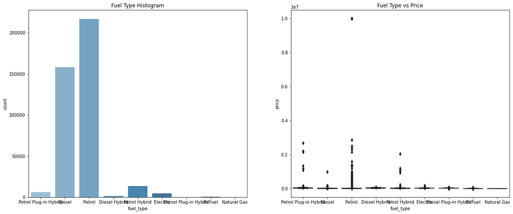

```python
plt.figure(figsize=(20,8))
plt.subplot(1,2,1)
plt.title('Fuel Type Histogram')
sns.countplot(x=data['fuel_type'], palette=('Blues_d')); #distribution of fuel type

plt.subplot(1,2,2)
plt.title('Fuel Type vs Price')
sns.boxplot(x=data['fuel_type'], y=data['price'], palette='PuBuGn'); # We can identify some noise in the data when we compare the fuel type against the price
```

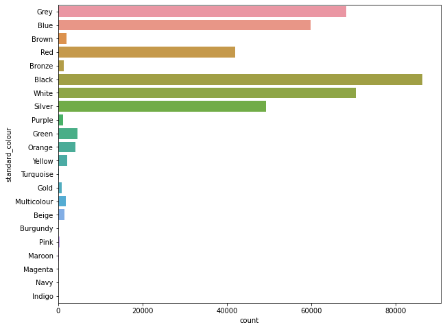

```python
plt.figure(figsize=(10,8))
sns.countplot(y=data['standard_colour']); #checking the distribution of the standard colour column - we can see that Black is the prevalent colour
```

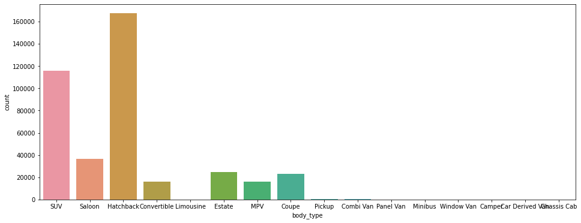

```python
plt.figure(figsize=(16,6))
sns.countplot(x = data['body_type']); #checking the distribution of the body type column - we can see that Hatchback is the most popular
```

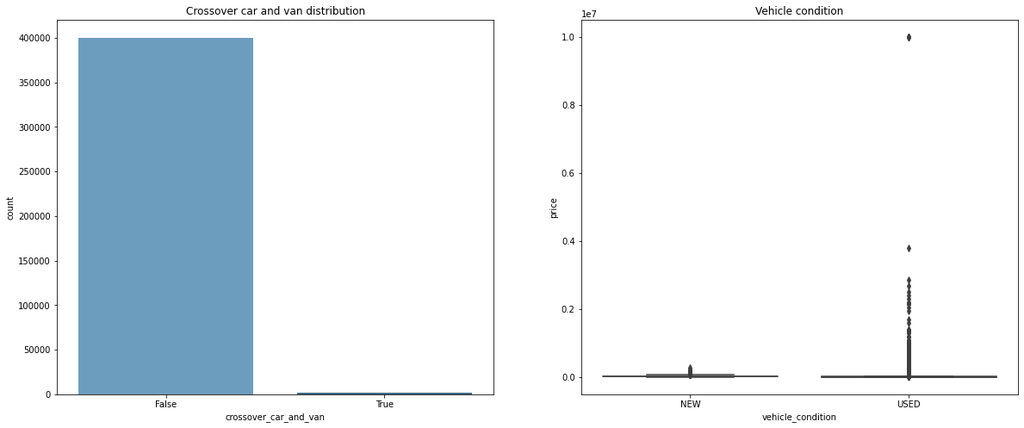

```python
plt.figure(figsize=(20,8))
plt.subplot(1,2,1)
plt.title('Crossover car and van distribution')
sns.countplot(x=data['crossover_car_and_van'], palette=('Blues_d'));
#distribution of the crossover car and van; we can see we have more non crossover than crossover

plt.subplot(1,2,2)
plt.title('Vehicle condition')
sns.boxplot(x=data['vehicle_condition'], y=data['price'], palette='PuBuGn');
# checking the distribution of the vehicle condition - and it appears there are lots of outliers in the vehicle condition when compared to price
```

```python
data.describe().round() #to view the numerical summary statistics across the columns in the dataset
```

|  | mileage | year_of_registration | price |
| --- | --- | --- | --- |
| count | 401523.0 | 368694.0 | 402005.0 |
| mean | 37777.0 | 2015.0 | 17342.0 |
| std | 34829.0 | 8.0 | 46437.0 |
| min | 0.0 | 999.0 | 120.0 |
| 25% | 10508.0 | 2013.0 | 7495.0 |
| 50% | 28680.0 | 2016.0 | 12600.0 |
| 75% | 56931.0 | 2018.0 | 20000.0 |
| max | 999999.0 | 2020.0 | 9999999.0 |

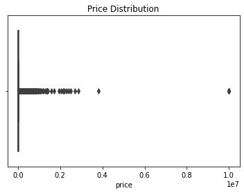

```python
plt.title('Price Distribution') #The price chart shows the prevalence of outliers in the price
sns.boxplot(x=data['price']);
```

# Data Processing

## Dealing with Missing Values, Outliers, and Noise

Dealing with missing values -

I will be dropping all other NaN values in the dataset

```python
data.isna().sum().sort_values() #the missing values after dropping the public reference and registration code column
```

```
standard_make                0
standard_model               0
vehicle_condition            0
price                        0
crossover_car_and_van        0
mileage                    482
fuel_type                  601
body_type                  837
standard_colour           5378
year_of_registration     33311
dtype: int64
```

```python
data['mileage'] = data['mileage'].fillna(data['mileage'].median()) #filling mileage NaN with the median because as we have seen earlier, outliers are much
data['year_of_registration'] = data['year_of_registration'].fillna(data['year_of_registration'].median())#filling year NaN with the median because as we have seen earlier, outliers are much
```

```python
data['body_type'].value_counts() #doing a value count on body type to see the popular body tyoe in the dataset
```

```
Hatchback          167315
SUV                115872
Saloon              36641
Estate              24692
Coupe               23258
Convertible         16038
MPV                 16026
Pickup                620
Combi Van             214
Limousine             159
Minibus               149
Camper                 77
Panel Van              61
Window Van             41
Chassis Cab             3
Car Derived Van         2
Name: body_type, dtype: int64
```

I will be dropping other nan values in the data set

```python
data = data.dropna() #drop nan values remaining in the data set
data.isna().sum() # to see if the code worked properly
```

```
mileage                  0
standard_colour          0
standard_make            0
standard_model           0
vehicle_condition        0
year_of_registration     0
price                    0
body_type                0
crossover_car_and_van    0
fuel_type                0
dtype: int64
```

```python
#I will convert the year of registration from float to int64
data['year_of_registration'] = data['year_of_registration'].astype(int)
```

```python
data.info()
```

```
<class 'pandas.core.frame.DataFrame'>
Int64Index: 395380 entries, 0 to 402004
Data columns (total 10 columns):
 #   Column                 Non-Null Count   Dtype
---  ------                 --------------   -----
 0   mileage                395380 non-null  float64
 1   standard_colour        395380 non-null  object
 2   standard_make          395380 non-null  object
 3   standard_model         395380 non-null  object
 4   vehicle_condition      395380 non-null  object
 5   year_of_registration   395380 non-null  int64
 6   price                  395380 non-null  int64
 7   body_type              395380 non-null  object
 8   crossover_car_and_van  395380 non-null  bool
 9   fuel_type              395380 non-null  object
dtypes: bool(1), float64(1), int64(2), object(6)
memory usage: 30.5+ MB
```

## Dealing with Noise and Outliers

**There are several ways in dealing with outliers, I will try to divide the dataset to reduce its impact. From the KDE distribution of year of registration, it is evident that we have only few data from year less than 2000, hence, I will be dividing the dataset with respect to years - year greater than 1999 and year less than 1999.**

```python
less_2000 = data.loc[data['year_of_registration'] < 2000] #for years less than 2000's
less_2000.sample()
```

|  | mileage | standard_colour | standard_make | standard_model | vehicle_condition | year_of_registration | price | body_type | crossover_car_and_van | fuel_type |
| --- | --- | --- | --- | --- | --- | --- | --- | --- | --- | --- |
| 48299 | 196000.0 | Black | Nissan | Primera | USED | 1996 | 950 | Saloon | False | Diesel |

```python
new_data = data.loc[data['year_of_registration'] > 2000] #for years less than 2000's
new_data.sample()
```

|  | mileage | standard_colour | standard_make | standard_model | vehicle_condition | year_of_registration | price | body_type | crossover_car_and_van | fuel_type |
| --- | --- | --- | --- | --- | --- | --- | --- | --- | --- | --- |
| 352183 | 39000.0 | Green | Aston Martin | Vanquish | USED | 2004 | 79850 | Coupe | False | Petrol |

```python
#checking the summary statistics of the new dataset and answering some questions about it.
new_data.info()
```

```
<class 'pandas.core.frame.DataFrame'>
Int64Index: 393090 entries, 0 to 402004
Data columns (total 10 columns):
 #   Column                 Non-Null Count   Dtype
---  ------                 --------------   -----
 0   mileage                393090 non-null  float64
 1   standard_colour        393090 non-null  object
 2   standard_make          393090 non-null  object
 3   standard_model         393090 non-null  object
 4   vehicle_condition      393090 non-null  object
 5   year_of_registration   393090 non-null  int64
 6   price                  393090 non-null  int64
 7   body_type              393090 non-null  object
 8   crossover_car_and_van  393090 non-null  bool
 9   fuel_type              393090 non-null  object
dtypes: bool(1), float64(1), int64(2), object(6)
memory usage: 30.4+ MB
```

### **Some Exploratory Data Analysis of the Subset Data**

To answer some few questions

```python
new_data.describe().round() #a summary statistics on dataframe gives an idea about the outliers before the visualizations
```

|  | mileage | year_of_registration | price |
| --- | --- | --- | --- |
| count | 393090.0 | 393090.0 | 393090.0 |
| mean | 37557.0 | 2015.0 | 17084.0 |
| std | 34462.0 | 4.0 | 45355.0 |
| min | 0.0 | 2001.0 | 180.0 |
| 25% | 10662.0 | 2014.0 | 7495.0 |
| 50% | 28620.0 | 2016.0 | 12567.0 |
| 75% | 56100.0 | 2018.0 | 19995.0 |
| max | 999999.0 | 2020.0 | 9999999.0 |

**What are the top body types vehicle in the data set?**

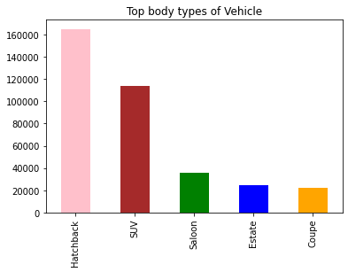

```python
#What are the top body_types vehicle in the data set?
plt.title('Top body types of Vehicle')
new_data['body_type'].value_counts().head().plot.bar(color={'orange','blue','green', 'pink', 'brown'});
```

**What are the top standard maker vehicle in the data set?**

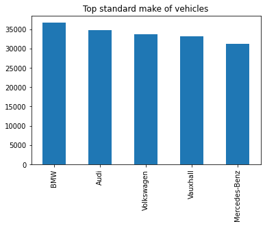

```python
#What are the top standard maker vehicle in the data set?
plt.title('Top standard make of vehicles')
new_data['standard_make'].value_counts().head().plot.bar();
```

**What are the distribution of vehicle condition in the data set?**

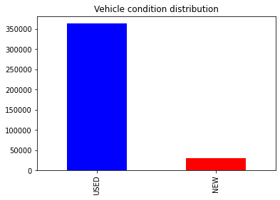

```python
#What are the distribution of vehicle condition in the data set?
plt.title('Vehicle condition distribution')
new_data['vehicle_condition'].value_counts().head().plot.bar(color={'red','blue'});
```

**What are the top colours of vehicle in the data?**

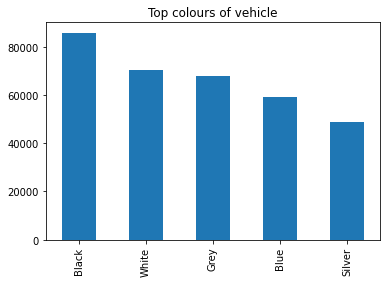

```python
#What are the colour of vehicles in the data set?
plt.title('Top colours of vehicle')
new_data['standard_colour'].value_counts().head().plot.bar();
```

**Does the Fuel type affect the price? How does the Fuel type affect price?**

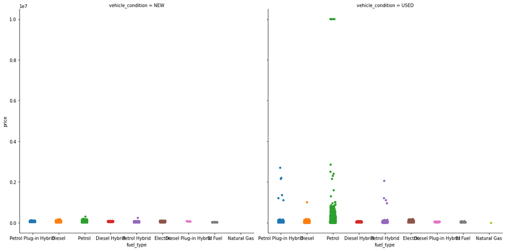

```python
#does vehicle condition affect price?
plt.figure(figsize=(10,10))
sns.catplot(data=new_data, col='vehicle_condition', x='fuel_type', y='price', height=8);
```

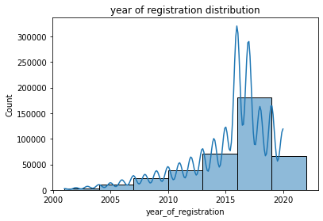

```python
#distribution of the year of vehicle in the data set
plt.title('year of registration distribution')
sns.histplot(data=new_data, x="year_of_registration", binwidth=3, kde=True);
```

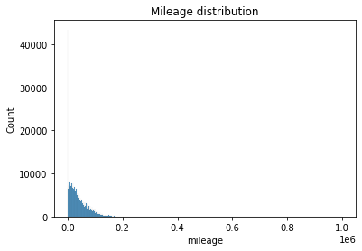

```python
#creating a histogram on the mileage to review it distribution again
plt.title('Mileage distribution')
sns.histplot(new_data['mileage']);
# the distribution is skewed, I will use the IQR to determine the outliers since the data doesnt follow a normal disribution
```

### multivariate analysis

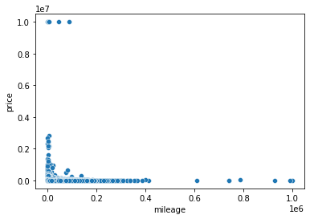

```python
sns.scatterplot(x=new_data['mileage'], y=new_data['price']);
#viewing the outliers that exist between mileage and price columns
```

Using the IQR, the outlier data points are the ones falling below Q1–1.5 IQR or above Q3 + 1.5 IQR. The Q1 is the 25th percentile and Q3 is the 75th percentile of the dataset, and IQR represents the interquartile range calculated by Q3 minus Q1 (Q3–Q1).[Inspired by](https://careerfoundry.com/en/blog/data-analytics/how-to-find-outliers/#:~:text=A%20box%20plot%20allows%20us,makes%20them%20easy%20to%20see)

```python
#creating a function to find the outliersin the dataframe
def find_outliers_IQR(new_data):

   q1=new_data.quantile(0.25)
   q3=new_data.quantile(0.75)
   IQR=q3-q1
   outliers = new_data[((new_data<(q1-1.5*IQR)) | (new_data>(q3+1.5*IQR)))]
   return outliers
```

```python
#Finding the outliers in the mileage column and price column
outliers_mileage = find_outliers_IQR(new_data['mileage'])
outliers_price = find_outliers_IQR(new_data['price'])
```

## Feature Engineering, Data Transformations

Replacing outliers in the dataset and Data Transfromation

```python
#replacing outliers in the mileage and price columns
def impute_outliers_IQR(new_data):
   q1=new_data.quantile(0.25)
   q3=new_data.quantile(0.75)
   IQR=q3-q1
   upper = new_data[~(new_data>(q3+1.5*IQR))].max()
   lower = new_data[~(new_data<(q1-1.5*IQR))].min()
   new_data = np.where(new_data > upper,
       new_data.median(),
       np.where(
           new_data < lower,
           new_data.median(),
           new_data
           )
       )
   return new_data
```

```python
new_data['mileage'] = impute_outliers_IQR(new_data['mileage']);
```

```python
new_data['price'] = impute_outliers_IQR(new_data['price']);
```

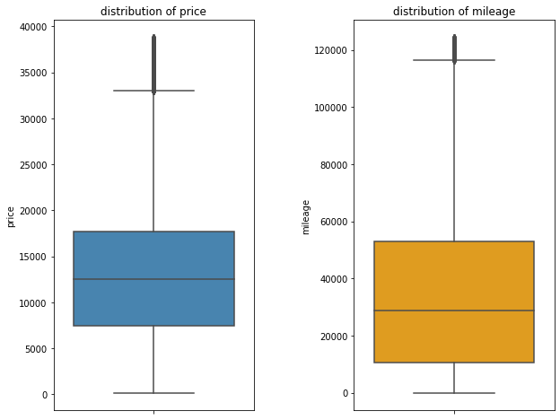

```python
plt.figure(figsize=(10,8))
plt.subplot(1,2,1)
plt.title('distribution of price')
sns.boxplot(y=new_data['price'], palette=('Blues_d')); #distribution of price
plt.subplot(1,2,2)
plt.title('distribution of mileage')
plt.subplots_adjust(wspace = 0.5)
sns.boxplot(y=new_data['mileage'], color='orange'); # dsitribution of mileage
```

Creating new features and Engineering Features

```python
new_data['price'].min(), new_data['price'].max()
#viewing the min and max values of price, in other to engineer a new feature
```

```
(180.0, 38744.0)
```

```python
new_data['mileage'].min(), new_data['mileage'].max()
#viewing the min and max values of mileage, in other to engineer a new feature
```

```
(0.0, 124251.0)
```

I am Engineering a new feature from mileage, the age of vehicle can be formulated from mileage, as the higher the mileage, the older the vehicle should be.

I have categories the mileage into groups:

1. 0 mileage = 0 year
2. 10,000 mileage = 1 year
3. 20,000 mileage = 2 year
4. 40,000 mileage = 4 year
5. 80,000 mileage = 8 year
6. 120,000 mileage = 12 year

*I am calling this feature **age** - and it will be a categorical feature*

```python
new_data['age'] =pd.cut(
new_data['mileage'],
bins=[0,10000,20000,40000,80000,120000,160000],
labels=[0,1,2,4,8,12],
right=False, include_lowest=True
)
```

I am also Engineering another feature from price **price_cat** , to categorize the price into **'Cheap', 'Affordable', 'Expensive' and 'Luxury'.**

I will be using this feature to answer some question later on.

```python
#creating a new feature - price category which represent the price categories of the vehicles.
new_data['price_cat'] =pd.cut(
new_data['price'],
bins=[180,5000,9700,19400,38800],
labels=['Cheap', 'Affordable','Expensive', 'Luxury'],
right=False, include_lowest=True
)
```

```python
new_data.sample()
```

|  | mileage | standard_colour | standard_make | standard_model | vehicle_condition | year_of_registration | price | body_type | crossover_car_and_van | fuel_type | age | price_cat |
| --- | --- | --- | --- | --- | --- | --- | --- | --- | --- | --- | --- | --- |
| 377725 | 27000.0 | Silver | Lexus | IS 300 | USED | 2016 | 17295.0 | Saloon | False | Petrol Hybrid | 2 | Expensive |